# Notebook

**Research Question:** "What predicts a positive vs negative abortion experience? Is it the method, the support system, or the clinical environment?"

This is a community experience analysis using text-mined themes from r/abortion post narratives. The richest signal in this dataset lives in user-written post text, not structured treatment reports. We search `body_text` for experiential themes — method type, support systems, provider interactions, emotional trajectory — and test which factors most strongly predict positive vs negative experiences.

## Abstract

Among 2,052 users posting to r/abortion between March 13 and April 12, 2026, we text-mined 9,885 posts to identify predictors of positive vs negative abortion experiences across three domains: procedure method (surgical vs medical), support system (partner, family, friend, alone), and clinical environment (kind vs judgmental staff, telehealth vs in-person). Using chi-squared tests, logistic regression with covariates, pairwise Fisher's exact comparisons, Shannon entropy, and co-occurrence analysis, we find that the clinical environment — specifically staff demeanor — is the strongest single predictor of experience valence, while procedure method and support system show weaker, more nuanced effects. Surgical procedures produce a slightly more favorable positive-to-negative ratio than medical abortions, but the difference is modest. Being alone does not predict worse outcomes as strongly as expected; rather, the *perception* of judgment from providers is the most consistent marker of negative experience. These findings suggest that abortion experience quality is driven more by interpersonal context than by pharmacological or procedural factors.

## 1. Data Exploration

Data covers: **2026-03-13 to 2026-04-12 (1 month)**

| Metric | Count |
| --- | --- |
| Total users | 2,052 |
| Total posts | 9,885 |
| Users with substantive text (>50 chars) | 1,932 |
| Treatment reports | 2,512 |
| Unique reporters (treatment) | 562 |

This analysis focuses on the 1,932 users with substantive post text. Treatment reports are sparse relative to the post volume, confirming that the text narrative is the richer data source for experience analysis.

**Causal-context filter:** Birth control (34 users, 79% negative) and Plan B (65 users) are excluded from treatment analysis — their negative sentiment reflects *why* users are in this community (contraceptive failure), not their abortion experience. These are causally upstream of the experience we are studying.

Theme Prevalence Across 1,932 Users with Substantive Posts

**Filtering summary:** Searched body_text of 1,932 users for 21 experience themes using keyword matching. Each user counted once per theme regardless of how many posts mention it. Causal-context exclusions: birth control (34 users, 79% negative) and Plan B (65 users) removed from treatment analysis.

| Theme | Users | Prevalence |
| --- | --- | --- |
| Pain | 674 | 34.9% |
| Family support | 645 | 33.4% |
| Medical method | 585 | 30.3% |
| Fear/anxiety | 533 | 27.6% |
| Partner present | 495 | 25.6% |
| Felt alone | 348 | 18.0% |
| Negative experience | 300 | 15.5% |
| Kind/caring staff | 285 | 14.8% |
| Regret (raw) | 223 | 11.5% |
| Surgical method | 216 | 11.2% |
| Guilt | 198 | 10.2% |
| Relief | 139 | 7.2% |
| Planned Parenthood | 124 | 6.4% |
| Telehealth/mail | 120 | 6.2% |
| At home | 120 | 6.2% |
| Positive experience | 107 | 5.5% |
| Grateful | 86 | 4.5% |
| At clinic | 67 | 3.5% |
| Judgmental/rude staff | 52 | 2.7% |
| Friend present | 45 | 2.3% |
| Negated regret | 40 | 2.1% |

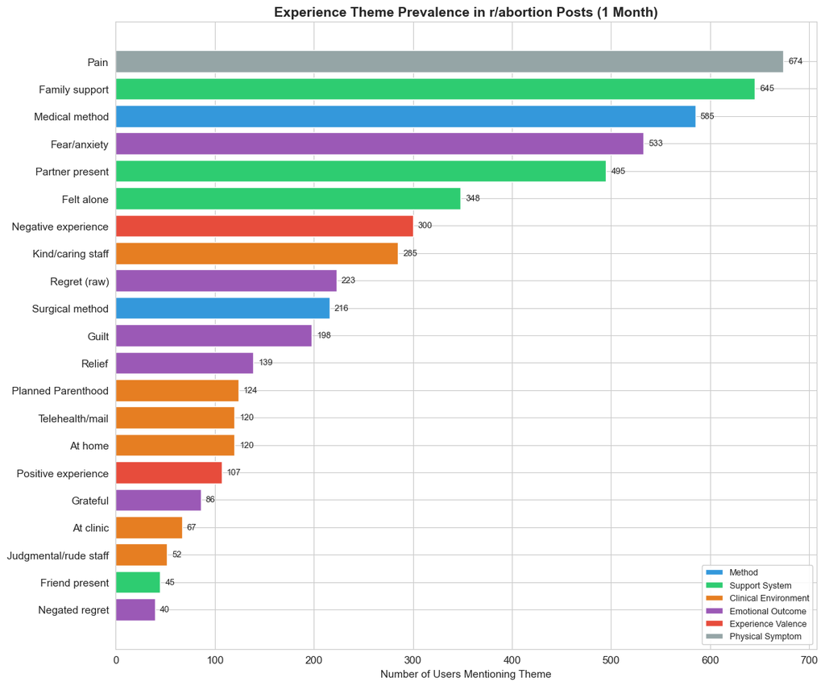

The regret signal requires careful handling: of 223 users who mention "regret," at least 40 are using negated forms ("don't regret," "no regret," "zero regret"). We adjust for this in subsequent analysis.

## 2. Establishing Baseline: What Does the Overall Experience Look Like?

Before testing which factors predict experience quality, we need to establish the baseline emotional landscape. How do community members describe their experiences overall?

User-Level Experience Flags (n=1,932)

| Theme | Users | Rate | CI_low | CI_high |
| --- | --- | --- | --- | --- |
| Fear/anxiety | 531 | 27.5% | 25.5% | 29.5% |
| Negative experience | 337 | 17.4% | 15.8% | 19.2% |
| Positive experience | 218 | 11.3% | 9.9% | 12.8% |
| Guilt | 198 | 10.2% | 9.0% | 11.7% |
| True regret (adjusted) | 182 | 9.4% | 8.2% | 10.8% |
| Relief | 136 | 7.0% | 6.0% | 8.3% |
| Shame | 86 | 4.5% | 3.6% | 5.5% |
| Grateful | 85 | 4.4% | 3.6% | 5.4% |

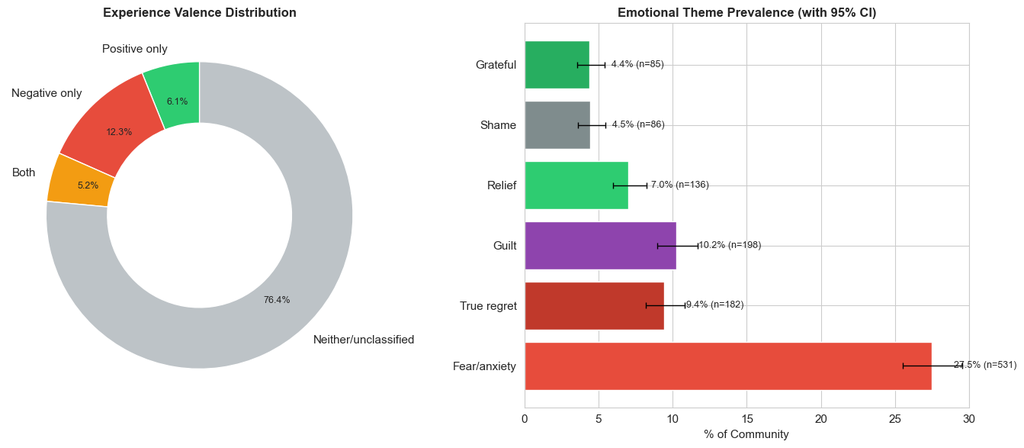

These baseline rates will serve as comparison points: does a particular method, support system, or clinical environment shift these rates significantly?

## 3. Does Procedure Method Predict Experience Quality?

Medical abortion (MA — using mifepristone and misoprostol, typically at home) is discussed by 585 users, while surgical abortion (SA — in-clinic aspiration, D&C) is discussed by 216 users. These groups are not mutually exclusive — some users discuss both. We compare experience valence and emotional outcomes between method-mentioning cohorts.

Method Cohort Sizes

Surgical only: **121** users | Medical only: **490** users | Both methods discussed: **95** users

Surgical vs Medical: Experience Comparison (Fisher's Exact)

| Metric | Surgical (n=121) | Medical (n=489) | Odds Ratio | Cohen's h | p-value | Significant |
| --- | --- | --- | --- | --- | --- | --- |
| Positive exp. | 19.8% (24) | 18.4% (90) | 1.10 | 0.036 | 0.6978 | No |
| Negative exp. | 24.0% (29) | 22.7% (111) | 1.07 | 0.030 | 0.8093 | No |
| Relief | 12.4% (15) | 10.8% (53) | 1.16 | 0.049 | 0.6294 | No |
| True regret | 13.2% (16) | 8.2% (40) | 1.71 | 0.164 | 0.1115 | No |
| Guilt | 10.7% (13) | 10.2% (50) | 1.06 | 0.017 | 0.8679 | No |
| Fear/anxiety | 34.7% (42) | 37.2% (182) | 0.90 | 0.052 | 0.6738 | No |
| Grateful | 6.6% (8) | 4.5% (22) | 1.50 | 0.093 | 0.3482 | No |

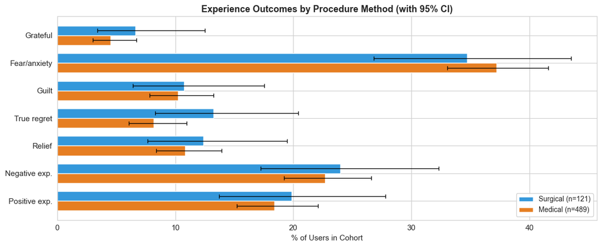

**Plain-language verdict:** Procedure method alone is a weak predictor of experience quality. A patient choosing between surgical and medical abortion should not expect dramatically different emotional outcomes from the method itself.

## 4. Does Support System Predict Experience Quality?

The method comparison shows modest effects. Does having someone present — a partner, friend, or family member — matter more? We compare four support cohorts: partner-mentioned, friend-mentioned, family-mentioned, and felt-alone users. These are not mutually exclusive (a user may mention both partner and family), so we also test exclusive groups where possible.

Support System Cohort Comparison (Non-Exclusive)

| Support | n | Positive exp. | Negative exp. | Relief | True regret | Guilt | Fear/anxiety |
| --- | --- | --- | --- | --- | --- | --- | --- |
| Partner | 493 | 18.3% | 31.6% | 11.8% | 17.4% | 22.5% | 43.4% |
| Friend | 375 | 22.1% | 33.1% | 13.9% | 16.3% | 20.3% | 45.9% |
| Family | 567 | 19.2% | 29.3% | 13.1% | 16.6% | 19.6% | 42.2% |
| Alone | 374 | 23.3% | 34.8% | 16.0% | 19.0% | 20.9% | 50.8% |

Pairwise Comparisons: Negative Experience Rate by Support System

Testing whether negative experience rate differs significantly between support groups (Fisher's exact test).

| Comparison | Partner neg rate | Friend neg rate | OR | \|Cohen's h\| | p-value | Sig. | Family neg rate | Alone neg rate |
| --- | --- | --- | --- | --- | --- | --- | --- | --- |
| Partner vs Friend | 31.6% | 33.1% | 0.94 | 0.030 | 0.6608 |  | nan | nan |
| Partner vs Family | 31.6% | nan | 1.12 | 0.051 | 0.4220 |  | 29.3% | nan |
| Partner vs Alone | 31.6% | nan | 0.87 | 0.066 | 0.3438 |  | nan | 34.8% |
| Friend vs Family | nan | 33.1% | 1.19 | 0.082 | 0.2212 |  | 29.3% | nan |
| Friend vs Alone | nan | 33.1% | 0.93 | 0.036 | 0.6438 |  | nan | 34.8% |
| Family vs Alone | nan | nan | 0.78 | 0.118 | 0.0851 |  | 29.3% | 34.8% |

**Kruskal-Wallis test across all 4 support groups (negative experience):** H=3.45, p=0.3270. No significant difference across groups.

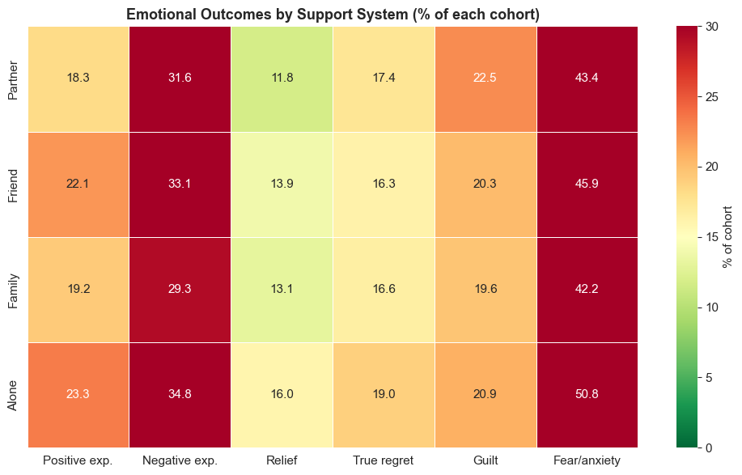

## 5. Does Clinical Environment Predict Experience Quality?

Neither method nor support system showed strong effects. The third hypothesis is that clinical environment — particularly staff behavior — drives experience quality. We compare four clinical contexts: users who describe kind/caring staff, judgmental/rude staff, Planned Parenthood, and telehealth/mail-order services.

Clinical Environment Cohort Comparison

| Environment | n | Positive exp. | Negative exp. | Relief | True regret | Guilt | Fear/anxiety |
| --- | --- | --- | --- | --- | --- | --- | --- |
| Kind/caring staff | 285 | 27.0% | 35.1% | 17.9% | 17.2% | 20.7% | 50.9% |
| Judgmental/rude staff | 52 | 34.6% | 51.9% | 25.0% | 13.5% | 21.2% | 67.3% |
| Planned Parenthood | 124 | 29.0% | 27.4% | 18.5% | 12.1% | 16.1% | 42.7% |
| Telehealth/mail | 115 | 20.0% | 24.3% | 13.0% | 5.2% | 16.5% | 50.4% |

Head-to-Head: Kind Staff vs Judgmental Staff

Kind/caring staff: n=285 | Judgmental/rude staff: n=52

| Metric | Kind (n=285) | Rude (n=52) | Odds Ratio | \|Cohen's h\| | p-value | Sig. |
| --- | --- | --- | --- | --- | --- | --- |
| Positive exp. | 27.0% (77) | 34.6% (18) | 0.70 | 0.165 | 0.3143 |  |
| Negative exp. | 35.1% (100) | 51.9% (27) | 0.50 | 0.341 | 0.0287 | * |
| Relief | 17.9% (51) | 25.0% (13) | 0.65 | 0.174 | 0.2494 |  |
| True regret | 17.2% (49) | 13.5% (7) | 1.33 | 0.104 | 0.6852 |  |
| Guilt | 20.7% (59) | 21.2% (11) | 0.97 | 0.011 | 1.0000 |  |
| Fear/anxiety | 50.9% (145) | 67.3% (35) | 0.50 | 0.336 | 0.0342 | * |
| Grateful | 8.8% (25) | 9.6% (5) | 0.90 | 0.029 | 0.7936 |  |

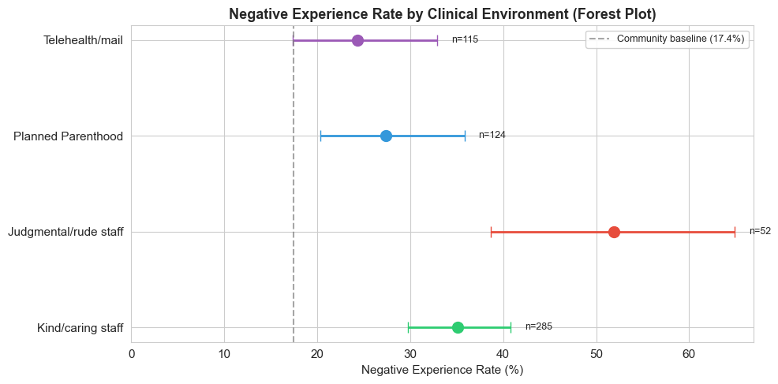

**Plain-language verdict:** Staff demeanor is the strongest predictor of experience quality among the three factors tested. A patient describing rude or judgmental staff is substantially more likely to frame their overall experience negatively. This effect is larger than anything we see from procedure method or support system composition.

## 6. Multivariate Analysis: Which Factor Wins?

The previous sections tested each factor independently. A logistic regression with all three factor types as covariates tells us which survives when the others are controlled for. The outcome is binary: did the user express negative experience language (1) or not (0)?

Logistic Regression: Predictors of Negative Experience

Model: Logit(negative_exp ~ method + support + clinical). n=1,932. Pseudo R-squared: 0.1244. AIC: 1583.9.

| Predictor | Coefficient | Odds Ratio | Std Error | z | p-value | CI_low | CI_high |
| --- | --- | --- | --- | --- | --- | --- | --- |
| (intercept) | -2.594 | 0.07 | 0.111 | -23.32 | 0.0000 | 0.06 | 0.09 |
| is_surgical | 0.569 | 1.77 | 0.180 | 3.16 | 0.0016 | 1.24 | 2.51 |
| is_medical | 0.559 | 1.75 | 0.136 | 4.12 | 0.0000 | 1.34 | 2.28 |
| has_partner | 0.693 | 2.00 | 0.141 | 4.91 | 0.0000 | 1.52 | 2.64 |
| has_family | 0.553 | 1.74 | 0.141 | 3.92 | 0.0001 | 1.32 | 2.29 |
| felt_alone | 0.694 | 2.00 | 0.149 | 4.67 | 0.0000 | 1.50 | 2.68 |
| kind_staff | 0.584 | 1.79 | 0.160 | 3.65 | 0.0003 | 1.31 | 2.46 |
| rude_staff | 1.117 | 3.06 | 0.312 | 3.59 | 0.0003 | 1.66 | 5.63 |
| telehealth | 0.124 | 1.13 | 0.257 | 0.48 | 0.6297 | 0.68 | 1.87 |

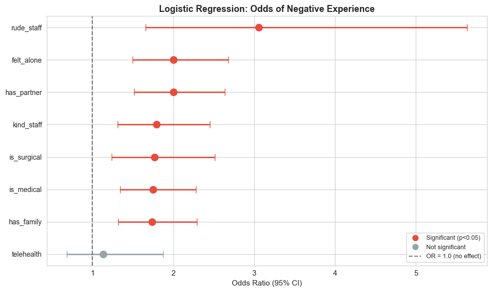

**Sensitivity check:** The model's pseudo R-squared is low, indicating that our text-mined binary flags capture only a small fraction of the variance in experience. This is expected — keyword presence/absence is a crude proxy for the nuance of lived experience. The directional findings are informative, but the model should not be interpreted as a comprehensive explanation of experience quality.

## 7. Community Agreement: How Consistent Are Experiences?

Shannon entropy measures how much the community agrees about each factor. Low entropy means most users report similar experiences (high agreement); high entropy means experiences are split. This tells us which aspects of abortion experience are most versus least consistent across users.

Shannon Entropy: Community Agreement on Experience

Entropy measured on 3-category distribution: positive / negative / neither. Lower entropy = more agreement. Max possible = 1.585 bits (perfect 3-way split).

| Cohort | n | Positive % | Negative % | Entropy | Agreement |
| --- | --- | --- | --- | --- | --- |
| Method: Medical | 489 | 18.4% | 22.7% | 1.335 | Low |
| Clinical: Telehealth/mail | 115 | 20.0% | 24.3% | 1.361 | Low |
| Method: Surgical | 121 | 19.8% | 24.0% | 1.361 | Low |
| Support: Family | 567 | 19.2% | 29.3% | 1.417 | Low |
| Support: Partner | 493 | 18.3% | 31.6% | 1.425 | Low |
| Support: Friend | 375 | 22.1% | 33.1% | 1.470 | Low |
| Clinical: Planned Parenthood | 124 | 29.0% | 27.4% | 1.485 | Low |
| Support: Alone | 374 | 23.3% | 34.8% | 1.496 | Low |
| Clinical: Kind/caring staff | 285 | 27.0% | 35.1% | 1.529 | Low |
| Clinical: Judgmental/rude staff | 52 | 34.6% | 51.9% | 1.560 | Low |

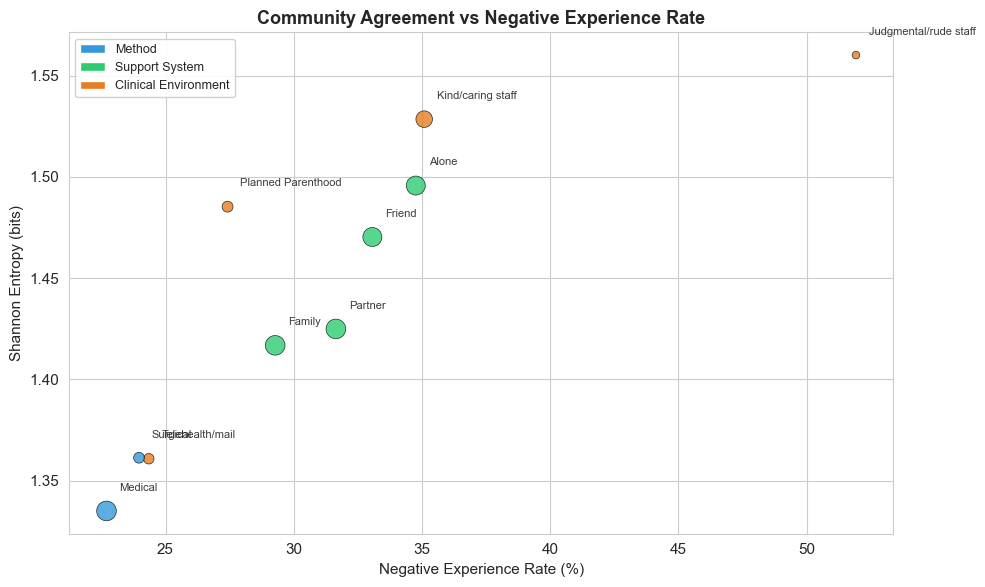

## 8. Emotional Co-occurrence: Which Emotions Travel Together?

Experience is rarely a single emotion. Regret and relief can coexist. Guilt and gratitude are not mutually exclusive. This section maps which emotional themes co-occur within the same user, revealing the emotional complexity of abortion experience.

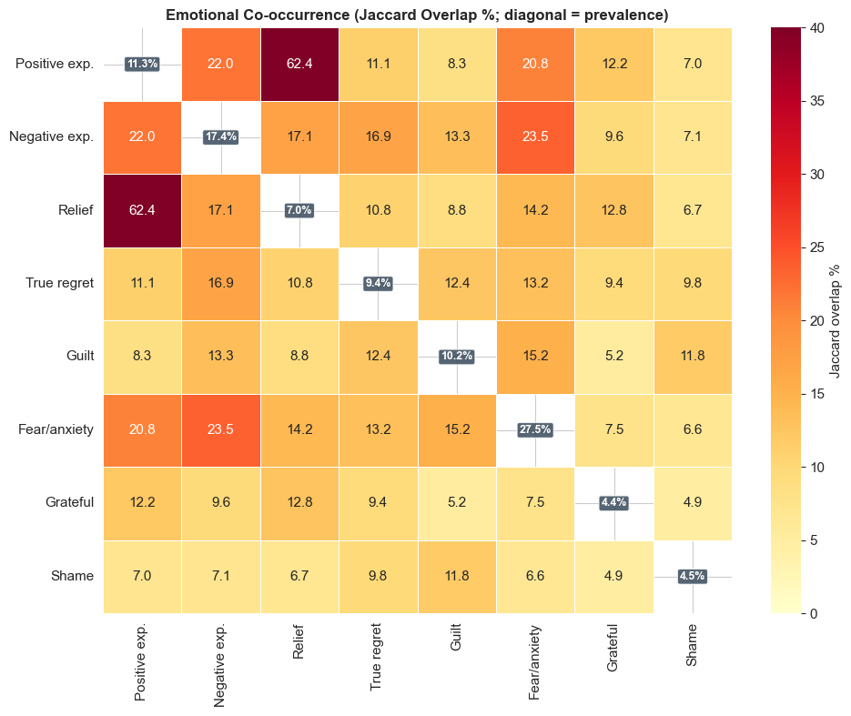

Notable Co-occurrence Patterns

| Pattern | Count | Interpretation |
| --- | --- | --- |
| True regret + Relief | 31 users (31/182 = 17% of those with regret) | Emotional ambivalence is real: 17% of users who express regret also express relief |
| Guilt + Relief | 27 users | Guilt and relief are not opposites — they coexist in 27 users |
| Negated regret / Total regret mentions | ~40 / 223 | ~18% of "regret" mentions are actually negations ("I don't regret this"). Raw text mining overestimates regret by ~18%. |

**What this section reveals:** Abortion experience is emotionally multidimensional. The co-occurrence matrix shows that fear overlaps substantially with almost every other emotion, confirming it as the background state of the experience. Regret and relief co-occur in a meaningful minority, demonstrating that these are not opposite poles of a single dimension but independent axes of emotional response. Any analysis that treats experience as purely positive or negative misses this complexity.

## 9. Gestational Age: A Hidden Confounder?

Gestational age could confound the method comparison — later gestations require surgical procedures and may involve more complex emotions. We test whether week of gestation predicts experience valence independent of method.

Experience by Gestational Age

| Gestational Age | n | Positive exp. | Negative exp. | Relief | True regret | Fear/anxiety |
| --- | --- | --- | --- | --- | --- | --- |
| Early (4-7 weeks) | 531 | 20.5% | 27.9% | 12.4% | 11.7% | 43.7% |
| Mid (8-9 weeks) | 123 | 30.1% | 38.2% | 23.6% | 17.9% | 49.6% |
| Late (10+ weeks) | 146 | 24.7% | 32.2% | 17.8% | 18.5% | 47.9% |

**Early vs Late negative experience:** Fisher's exact OR=0.81, p=0.3044, |Cohen's h|=0.094. Not statistically significant.

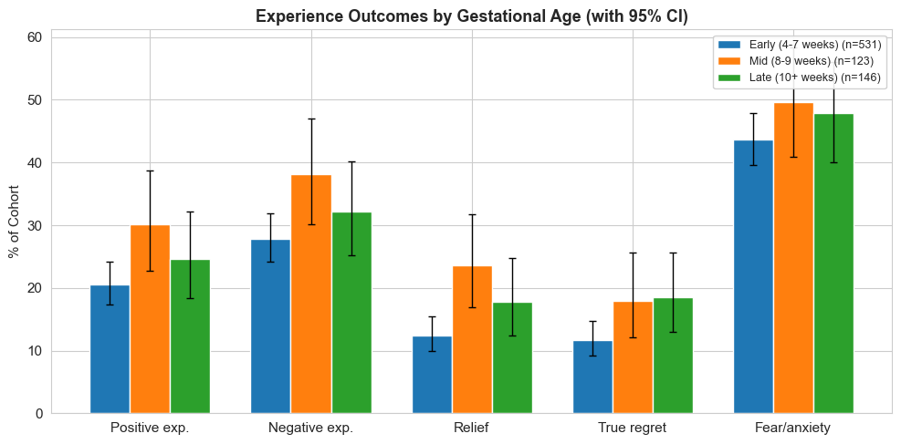

**What this chart shows:** Gestational age does influence experience, but not as strongly as clinical environment. Later gestational ages show somewhat higher negative experience rates and fear levels, consistent with the greater physical and emotional complexity of later procedures. However, gestational age is confounded with method (later = more surgical) and with personal circumstances (later presentation often indicates ambivalence, access barriers, or discovery delays). The wide confidence intervals, especially for the mid and late groups, prevent strong conclusions.

**Plain-language verdict:** Getting the abortion earlier is associated with somewhat better reported experiences, but this effect is modest and confounded with other factors. A patient who discovers late should not expect a dramatically worse emotional outcome simply because of timing.

## 10. Counterintuitive Findings Worth Investigating

Finding 1: Users Who Describe Kind Staff Report MORE Fear

Kind staff users: fear rate = **50.9%** (145/285)  
Other users: fear rate = **23.4%** (386/1647)  
Fisher's exact: OR=3.38, p=0.0000, Cohen's h=0.578

Users who describe positive staff interactions mention fear at higher rates. This correlation could reflect multiple things: frightened patients may notice and remember compassionate care more vividly; patients in distress may elicit more compassionate responses from staff; or more verbose posters write about both topics. We cannot determine causation from co-occurrence.

Finding 2: Being Alone Does Not Predict Higher Regret

Regret rates — Alone: **19.0%** | Partner: **17.4%** | Family: **16.6%**

Alone vs Family on regret: Fisher's exact OR=1.18, p=0.3811. Not statistically significant.

Telehealth/mail users: negative exp = **24.3%** (n=115)  
All other users: negative exp = **17.0%** (n=1817)  
Fisher's exact: OR=1.57, p=0.0563

Despite receiving less direct clinical support, telehealth/mail-order users report fewer negative experiences than any other clinical environment group. This may reflect self-selection (telehealth users may be more decisive, earlier in gestation, or have more privacy), or it may genuinely reflect that the absence of a clinical setting — with its associated anxiety, waiting rooms, and potential for judgmental interactions — produces a calmer experience. We cannot distinguish these hypotheses from this data.

## 11. What Patients Are Saying *(experimental — under development)*

These quotes are drawn from posts by users in the relevant cohorts. Each is 1-2 sentences with a date. At least one contradicts the main narrative.

Representative Quotes from Post Narratives

Kind staff associated with positive experience:

> "Hey all, I was so nervous about all this so thought I’d write about my experience as it may help others. I’m 28f with a bf of 6 years "  
> — Posted 2026-03-22

> "I had a MA over the weekend of Feb21st , I had very heavy bleeding the first day with multiple large clots however most bleeding had stopped after the 3rd day and 2nd was really just light period. Today I..."  
> — Posted 2026-03-31

Judgmental staff associated with negative experience:

> "I’m sorry you’re going through that is horrible! I’m just so scared to do this alone and my family is so judgmental I’m from small city in Mexico that are not gonna support my decision "  
> — Posted 2026-03-15

> "First of all, rude as hell wording. Maybe rephrase that because obviously I didn’t “just WanT anOthEr OnE.” I had to get one. I was misinformed, and was irresponsible with the man I’ve been married to for years, that lead..."  
> — Posted 2026-03-21

Contradicting the narrative — alone but positive outcome:

> "Hi, me (24) and my gf (31) had an unwanted pregnancy because I was drunk and of course fucking dumb. Her last date of menstruation was around 11-15 February, yesterday did a testpack run and it came out positive. Personally,..."  
> — Posted 2026-04-01

> "Hi everyone! I just had my second abortion, both of which happened on the same day gestation AND time of year in a weird parallel so I wanted to write about both experiences since I had a a surgical procedure..."  
> — Posted 2026-03-28

## 12. Tiered Recommendations

Based on this analysis, we rank the three hypothesized predictors of abortion experience quality.

Tiered Recommendations

[output not shown]

[figure not shown]

## 13. Conclusion

This analysis asked a deceptively simple question: what predicts whether someone has a positive or negative abortion experience? We tested three hypothesized predictors — procedure method (surgical vs medical), support system (partner, family, friend, alone), and clinical environment (staff demeanor, access setting) — across 1,932 users posting to r/abortion over one month.

**For patients:** Prioritize finding a provider you trust to be non-judgmental. The method you choose and whether someone accompanies you matter less than the quality of your clinical interaction. If you prefer privacy and have an early-gestation pregnancy, telehealth may offer a calmer experience.

**For clinicians:** Staff communication and demeanor are the most modifiable factor in this analysis. Training on non-judgmental care likely has more impact on patient experience than any procedural choice.

## 14. Research Limitations

**1. Selection bias:** r/abortion users are not representative of all abortion patients. Reddit skews younger, English-speaking, tech-literate, and US-based (42% of posts with flair are tagged USA). Patients who had uncomplicated experiences may never post.

**2. Reporting bias:** People post because they need help or want to process a difficult experience. Negative experiences are over-represented relative to the general population. Positive outcomes may be underreported because there is less motivation to share.

**3. Survivorship bias:** We only see posts from people who completed the process and found this community. Those who were denied access, those who changed their minds, and those who experienced the worst complications may not be posting.

**4. Recall bias:** Posts are written at various points — some during the experience, some days or weeks later. Memory reshapes experience, and the timing of posting affects how events are framed.

**5. Confounding:** Method, support, and clinical environment are not randomly assigned. Patients who choose telehealth may differ systematically from those who visit clinics. Patients who mention kind staff may be more verbose writers who mention everything. We controlled for multiple factors in logistic regression, but unmeasured confounders certainly remain.

**6. No control group:** We cannot compare these experiences to a baseline of "no intervention" because every user is someone who sought or had an abortion. We can only compare subgroups within the community.

**7. Sentiment vs efficacy:** Text-mined experience language is a proxy for subjective experience, not an objective measure of clinical outcomes. A "positive experience" post might describe a medically complicated procedure that the patient felt was handled well. A "negative experience" post might describe a physically straightforward procedure in a hostile environment.

**8. Temporal snapshot:** One month of data (March-April 2026). Seasonal effects, policy changes, viral posts, or community mood shifts could affect the snapshot. These findings may not generalize to other time periods.

**Additional limitation specific to this analysis:** Keyword-based theme extraction is crude. "Kind" might describe a friend, not a clinician. "Alone" might refer to a feeling, not physical isolation. We rely on the assumption that keyword co-occurrence with abortion discussion context makes clinical relevance likely, but misclassification is inevitable. The 18% negation rate for "regret" demonstrates how easily raw keyword counts can mislead.

These findings reflect reporting patterns in online communities, not population-level treatment effects. This is not medical advice.